# NFL Challange

## Import Modules and Data

```python
import pandas as pd
from sklearn.dummy import DummyRegressor
import matplotlib.pyplot as plt
import seaborn as sns
import datetime
import numpy as np
from geopy.geocoders import Nominatim
pd.options.mode.chained_assignment = None
%matplotlib inline
import mpl_toolkits
import matplotlib.pylab as plt
import plotly.plotly as py
import plotly.graph_objs as go
from sklearn import preprocessing as prep
from sklearn.base import BaseEstimator, TransformerMixin
from sklearn.ensemble import RandomForestClassifier
from sklearn.linear_model import Lasso, LinearRegression, LogisticRegression, Ridge, SGDClassifier
from sklearn.metrics import accuracy_score, mean_squared_error
from sklearn.model_selection import train_test_split, GridSearchCV, cross_val_score, ShuffleSplit, StratifiedKFold
from sklearn.pipeline import FeatureUnion, Pipeline
from sklearn.preprocessing import Imputer, LabelEncoder, StandardScaler, OneHotEncoder
from sklearn.svm import SVC, SVR
from sklearn.utils import check_array
#from sklearn_pandas import CategoricalImputer
from time import time
import warnings
warnings.simplefilter("ignore", category=PendingDeprecationWarning)
from sklearn.utils import check_array
from sklearn.preprocessing import LabelEncoder
from scipy import sparse, stats
```

```python
nfl_stadiums=pd.read_csv("./nfl-scores-and-betting-data/nfl_stadiums.csv",encoding = "utf-8")
nfl_teams=pd.read_csv("./nfl-scores-and-betting-data/nfl_teams.csv",encoding = "utf-8")
nfl_scores=pd.read_csv("./nfl-scores-and-betting-data/spreadspoke_scores.csv",encoding = "utf-8")
```

## Functions

```python
def count_null(df,column):
    try:
        for x in column:
            null=sum(pd.isnull(df[x]))
            print(x,null)
    except Exception:
            pass
class DataFrameSelector(BaseEstimator, TransformerMixin):
    def __init__(self, attribute_names):
        self.attribute_names = attribute_names
    def fit(self, X, y=None):
        return self
    def transform(self, X):
        return X[self.attribute_names].values
class CategoricalEncoder(BaseEstimator, TransformerMixin):
    def __init__(self, encoding='onehot', categories='auto', dtype=np.float64,
                 handle_unknown='error'):
        self.encoding = encoding
        self.categories = categories
        self.dtype = dtype
        self.handle_unknown = handle_unknown

    def fit(self, X, y=None):

        if self.encoding not in ['onehot', 'onehot-dense', 'ordinal']:
            template = ("encoding should be either 'onehot', 'onehot-dense' "
                        "or 'ordinal', got %s")
            raise ValueError(template % self.handle_unknown)

        if self.handle_unknown not in ['error', 'ignore']:
            template = ("handle_unknown should be either 'error' or "
                        "'ignore', got %s")
            raise ValueError(template % self.handle_unknown)

        if self.encoding == 'ordinal' and self.handle_unknown == 'ignore':
            raise ValueError("handle_unknown='ignore' is not supported for"
                             " encoding='ordinal'")

        X = check_array(X, dtype=np.object, accept_sparse='csc', copy=True)
        n_samples, n_features = X.shape

        self._label_encoders_ = [LabelEncoder() for _ in range(n_features)]

        for i in range(n_features):
            le = self._label_encoders_[i]
            Xi = X[:, i]
            if self.categories == 'auto':
                le.fit(Xi)
            else:
                valid_mask = np.in1d(Xi, self.categories[i])
                if not np.all(valid_mask):
                    if self.handle_unknown == 'error':
                        diff = np.unique(Xi[~valid_mask])
                        msg = ("Found unknown categories {0} in column {1}"
                               " during fit".format(diff, i))
                        raise ValueError(msg)
                le.classes_ = np.array(np.sort(self.categories[i]))

        self.categories_ = [le.classes_ for le in self._label_encoders_]

        return self

    def transform(self, X):
        X = check_array(X, accept_sparse='csc', dtype=np.object, copy=True)
        n_samples, n_features = X.shape
        X_int = np.zeros_like(X, dtype=np.int)
        X_mask = np.ones_like(X, dtype=np.bool)

        for i in range(n_features):
            valid_mask = np.in1d(X[:, i], self.categories_[i])

            if not np.all(valid_mask):
                if self.handle_unknown == 'error':
                    diff = np.unique(X[~valid_mask, i])
                    msg = ("Found unknown categories {0} in column {1}"
                           " during transform".format(diff, i))
                    raise ValueError(msg)
                else:
                    # Set the problematic rows to an acceptable value and
                    # continue `The rows are marked `X_mask` and will be
                    # removed later.
                    X_mask[:, i] = valid_mask
                    X[:, i][~valid_mask] = self.categories_[i][0]
            X_int[:, i] = self._label_encoders_[i].transform(X[:, i])

        if self.encoding == 'ordinal':
            return X_int.astype(self.dtype, copy=False)

        mask = X_mask.ravel()
        n_values = [cats.shape[0] for cats in self.categories_]
        n_values = np.array([0] + n_values)
        indices = np.cumsum(n_values)

        column_indices = (X_int + indices[:-1]).ravel()[mask]
        row_indices = np.repeat(np.arange(n_samples, dtype=np.int32),
                                n_features)[mask]
        data = np.ones(n_samples * n_features)[mask]

        out = sparse.csc_matrix((data, (row_indices, column_indices)),
                                shape=(n_samples, indices[-1]),
                                dtype=self.dtype).tocsr()
        if self.encoding == 'onehot-dense':
            return out.toarray()
        else:
            return out
def ttest(control, treatment):
    #paired t-test; two-tailed p-value      A   ,    B
    (t_score, p_value) = stats.ttest_rel(control, treatment)

    if p_value > 0.05/2:  #Two sided
        print('There is no significant difference between the two machine learning pipelines (Accept H0)')
    else:
        print('The two machine learning pipelines are different (reject H0) \n(t_score, p_value) = (%.2f, %.5f)'%(t_score, p_value) )
        if t_score > 0.0: #in the case of regression lower RMSE is better; A is lower
            print('Machine learning pipeline A is better than B')
        else:
            print('Machine learning pipeline B is better than A')
    return p_value
```

## Fix Nulls

```python
column_teams=list(nfl_teams.columns)
column_scores=list(nfl_scores.columns)
column_stadiums=list(nfl_stadiums.columns)
```

```python
#What the scores table looks like
nfl_scores.head()
```

|  | schedule_date | schedule_season | schedule_week | team_home | team_away | stadium | team_favorite_id | spread_favorite | over_under_line | weather_detail | weather_temperature | weather_wind_mph | weather_humidity | score_home | score_away | stadium_neutral | schedule_playoff |
| --- | --- | --- | --- | --- | --- | --- | --- | --- | --- | --- | --- | --- | --- | --- | --- | --- | --- |
| 0 | 9/2/1966 | 1966 | 1 | Miami Dolphins | Oakland Raiders | Orange Bowl | NaN | NaN | NaN | NaN | 83.0 | 6.0 | 71 | 14.0 | 23.0 | False | False |
| 1 | 9/3/1966 | 1966 | 1 | Houston Oilers | Denver Broncos | Rice Stadium | NaN | NaN | NaN | NaN | 81.0 | 7.0 | 70 | 45.0 | 7.0 | False | False |
| 2 | 9/4/1966 | 1966 | 1 | San Diego Chargers | Buffalo Bills | Balboa Stadium | NaN | NaN | NaN | NaN | 70.0 | 7.0 | 82 | 27.0 | 7.0 | False | False |
| 3 | 9/9/1966 | 1966 | 2 | Miami Dolphins | New York Jets | Orange Bowl | NaN | NaN | NaN | NaN | 82.0 | 11.0 | 78 | 14.0 | 19.0 | False | False |
| 4 | 9/10/1966 | 1966 | 1 | Green Bay Packers | Baltimore Colts | Lambeau Field | NaN | NaN | NaN | 64 degrees- humidity 62%- wind 8 mph | 64.0 | 8.0 | 62 | 24.0 | 3.0 | False | False |

### Nulls for NFL Scores

**Actions in this Section**

- Convert the date to a datetime format.
- Drop unceccary rows where nulls exists.
- Use only rows where games happened after 1980 due to a lot of nulls before 1980.

```python
#Current Nulls
count_null(nfl_scores,column_scores)
```

```
schedule_date 0
schedule_season 0
schedule_week 0
team_home 0
team_away 0
stadium 0
team_favorite_id 2601
spread_favorite 2601
over_under_line 2611
weather_detail 7930
weather_temperature 724
weather_wind_mph 724
weather_humidity 4013
score_home 135
score_away 135
stadium_neutral 0
schedule_playoff 0
```

```python
nfl_scores["schedule_date"]=pd.to_datetime(nfl_scores["schedule_date"])
nfl_scores.dropna(subset=["score_home","over_under_line","weather_temperature","weather_wind_mph"], inplace=True)
nfl_scores=nfl_scores[nfl_scores['schedule_date'].dt.year >= 1980]
```

```python
nfl_scores.drop(["weather_humidity","weather_detail","schedule_date","schedule_playoff"], axis=1,inplace=True)
```

```python
nfl_scores.loc[(nfl_scores.schedule_week == '18'), 'schedule_week'] = '17'
nfl_scores.loc[(nfl_scores.schedule_week == 'Wildcard') | (nfl_scores.schedule_week == 'WildCard'), 'schedule_week'] = '18'
nfl_scores.loc[(nfl_scores.schedule_week == 'Division'), 'schedule_week'] = '19'
nfl_scores.loc[(nfl_scores.schedule_week == 'Conference'), 'schedule_week'] = '20'
nfl_scores.loc[(nfl_scores.schedule_week == 'Superbowl') | (nfl_scores.schedule_week == 'SuperBowl'), 'schedule_week'] = '21'
nfl_scores['schedule_week'] = nfl_scores.schedule_week.astype(int)
```

```python
count_null(nfl_scores,column_scores)
```

```
schedule_season 0
schedule_week 0
team_home 0
team_away 0
stadium 0
team_favorite_id 0
spread_favorite 0
over_under_line 0
weather_temperature 0
weather_wind_mph 0
score_home 0
score_away 0
stadium_neutral 0
```

```python
nfl_scores.head()
```

|  | schedule_season | schedule_week | team_home | team_away | stadium | team_favorite_id | spread_favorite | over_under_line | weather_temperature | weather_wind_mph | score_home | score_away | stadium_neutral |
| --- | --- | --- | --- | --- | --- | --- | --- | --- | --- | --- | --- | --- | --- |
| 2734 | 1980 | 1 | Buffalo Bills | Miami Dolphins | Ralph Wilson Stadium | MIA | -3.0 | 35 | 64.0 | 8.0 | 17.0 | 7.0 | False |
| 2735 | 1980 | 1 | Cincinnati Bengals | Tampa Bay Buccaneers | Cinergy Field | TB | -1.0 | 34 | 72.0 | 9.0 | 12.0 | 17.0 | False |
| 2736 | 1980 | 1 | Green Bay Packers | Chicago Bears | Lambeau Field | CHI | -6.0 | 35 | 65.0 | 5.0 | 12.0 | 6.0 | False |
| 2737 | 1980 | 1 | Kansas City Chiefs | Oakland Raiders | Arrowhead Stadium | KC | -3.0 | 42 | 82.0 | 10.0 | 14.0 | 27.0 | False |
| 2738 | 1980 | 1 | Los Angeles Rams | Detroit Lions | Anaheim Stadium | LAR | -9.0 | 38 | 66.0 | 11.0 | 20.0 | 41.0 | False |

### Nulls for NFL Teams

```python
count_null(nfl_teams,column_teams)
```

```
team_name 0
team_name_short 0
team_id 0
team_id_pfr 0
team_conference 0
team_division 8
team_conference_pre2002 0
team_division_pre2002 2
```

```python
nfl_teams.head()
```

|  | team_name | team_name_short | team_id | team_id_pfr | team_conference | team_division | team_conference_pre2002 | team_division_pre2002 |
| --- | --- | --- | --- | --- | --- | --- | --- | --- |
| 0 | Arizona Cardinals | Cardinals | ARI | CRD | NFC | NFC West | NFC | NFC West |
| 1 | Phoenix Cardinals | Cardinals | ARI | CRD | NFC | NaN | NFC | NFC East |
| 2 | St. Louis Cardinals | Cardinals | ARI | ARI | NFC | NaN | NFC | NFC East |
| 3 | Atlanta Falcons | Falcons | ATL | ATL | NFC | NFC South | NFC | NFC West |
| 4 | Baltimore Ravens | Ravens | BAL | RAV | AFC | AFC North | AFC | AFC Central |

```python
null_columns=nfl_teams.columns[nfl_teams.isnull().any()]
print(nfl_teams[nfl_teams["team_division_pre2002"].isnull()][null_columns])
```

```
   team_division team_division_pre2002
14     AFC South                   NaN
26           NaN                   NaN
```

### Nulls for NFL Stadiums

**Actions in this Section**

- Fill in nulls of stadium close with 2018 for better visualizations.
- Fill in the NA of the Lat, Long and Elevation with 0's for easy manipulation.
- Drop Stadium Close with nulls
- Drop Unneccesary columns.
- Fill in missing lattitude and Longitude with accurate geopoints.

```python
nfl_stadiums['stadium_close'] = nfl_stadiums['stadium_close'].fillna(2018)
nfl_stadiums['LATITUDE'] = nfl_stadiums['LATITUDE'].fillna(0)
nfl_stadiums['LONGITUDE'] = nfl_stadiums['LONGITUDE'].fillna(0)
nfl_stadiums['ELEVATION'] = nfl_stadiums['ELEVATION'].fillna(0)
nfl_stadiums=nfl_stadiums[(nfl_stadiums['stadium_close'] >= 1980)]
count_null(nfl_stadiums,column_stadiums)
```

```
stadium_name 0
stadium_location 0
stadium_open 23
stadium_close 0
stadium_type 7
stadium_address 9
stadium_weather_station_code 10
stadium_weather_type 7
stadium_capacity 58
stadium_surface 45
STATION 44
NAME 44
LATITUDE 0
LONGITUDE 0
ELEVATION 0
```

```python
print(len(nfl_stadiums))

nfl_stadiums.head(5)
```

```
96
```

|  | stadium_name | stadium_location | stadium_open | stadium_close | stadium_type | stadium_address | stadium_weather_station_code | stadium_weather_type | stadium_capacity | stadium_surface | STATION | NAME | LATITUDE | LONGITUDE | ELEVATION |
| --- | --- | --- | --- | --- | --- | --- | --- | --- | --- | --- | --- | --- | --- | --- | --- |
| 0 | Alamo Dome | San Antonio, TX | NaN | 2018.0 | indoor | 100 Montana St, San Antonio, TX 78203 | 78203 | dome | 72000 | FieldTurf | NaN | NaN | 0.0000 | 0.0000 | 0.0 |
| 1 | Alltel Stadium | Jacksonville, FL | NaN | 2018.0 | NaN | NaN | NaN | NaN | NaN | NaN | NaN | NaN | 0.0000 | 0.0000 | 0.0 |
| 2 | Alumni Stadium | Chestnut Hill, MA | NaN | 2018.0 | outdoor | Perimeter Rd, Chestnut Hill, MA 02467 | 2467 | cold | NaN | Grass | NaN | NaN | 0.0000 | 0.0000 | 0.0 |
| 3 | Anaheim Stadium | Anaheim, CA | 1980.0 | 1994.0 | outdoor | 2000 E Gene Autry Way, Anaheim, CA 92806 | 92806 | warm | NaN | NaN | NaN | NaN | 0.0000 | 0.0000 | 0.0 |
| 4 | Arrowhead Stadium | Kansas City, MO | 1972.0 | 2018.0 | outdoor | 1 Arrowhead Dr, Kansas City, MO 64129 | 64129 | cold | 76,416 | Grass | US1MOJC0028 | KANSAS CITY 5.1 SE, MO US | 39.0692 | -94.4871 | 264.9 |

```python
#Fills in the Latitude, Longitude and Elevation where it is missing.
geolocator = Nominatim(user_agent="NFL")
for i, row in nfl_stadiums.iterrows():
    try:
        if nfl_stadiums.LATITUDE[i]==0:
            location = geolocator.geocode(nfl_stadiums.stadium_address[i])
            nfl_stadiums.LATITUDE[i]=location.latitude
            nfl_stadiums.LONGITUDE[i]=location.longitude
            nfl_stadiums.ELEVATION[i]=location.altitude
        else:
            pass
    except:
        pass
```

```python
#drop unnecessary tables
nfl_stadiums.dropna(subset=["stadium_open"], inplace=True)
nfl_stadiums.drop(["NAME","stadium_surface", "stadium_capacity", "STATION","stadium_weather_station_code"], axis=1,inplace=True)
```

```python
nfl_stadiums['stadium_close'] = nfl_stadiums['stadium_close'].fillna(2020)
nfl_stadiums['LATITUDE'] = nfl_stadiums['LATITUDE'].fillna(0)
nfl_stadiums['LONGITUDE'] = nfl_stadiums['LONGITUDE'].fillna(0)
nfl_stadiums['ELEVATION'] = nfl_stadiums['ELEVATION'].fillna(0)
nfl_stadiums=nfl_stadiums[(nfl_stadiums['stadium_close'] >= 1980)]
```

```python
geolocator = Nominatim(user_agent="NFL")
for i, row in nfl_stadiums.iterrows():
    try:
        if nfl_stadiums.LATITUDE[i]==0:
            location = geolocator.geocode(nfl_stadiums.stadium_address[i])
            nfl_stadiums.LATITUDE[i]=location.latitude
            nfl_stadiums.LONGITUDE[i]=location.longitude
            nfl_stadiums.ELEVATION[i]=location.altitude
        else:
            pass
    except:
        pass
```

```python
nfl_stadiums.dropna(subset=["stadium_open"], inplace=True)
nfl_stadiums.drop(["NAME","stadium_surface", "stadium_capacity", "STATION","stadium_weather_station_code"], axis=1,inplace=True)
```

```python
count_null(nfl_stadiums,column_stadiums)
```

```
stadium_name 0
stadium_location 0
stadium_open 0
stadium_close 0
stadium_type 0
stadium_address 0
```

## EDA

### EDA for NFL_Scores

```python
nfl_scores.head()
```

|  | schedule_season | schedule_week | team_home | team_away | stadium | team_favorite_id | spread_favorite | over_under_line | weather_temperature | weather_wind_mph | score_home | score_away | stadium_neutral |
| --- | --- | --- | --- | --- | --- | --- | --- | --- | --- | --- | --- | --- | --- |
| 2734 | 1980 | 1 | Buffalo Bills | Miami Dolphins | Ralph Wilson Stadium | MIA | -3.0 | 35 | 64.0 | 8.0 | 17.0 | 7.0 | False |
| 2735 | 1980 | 1 | Cincinnati Bengals | Tampa Bay Buccaneers | Cinergy Field | TB | -1.0 | 34 | 72.0 | 9.0 | 12.0 | 17.0 | False |
| 2736 | 1980 | 1 | Green Bay Packers | Chicago Bears | Lambeau Field | CHI | -6.0 | 35 | 65.0 | 5.0 | 12.0 | 6.0 | False |
| 2737 | 1980 | 1 | Kansas City Chiefs | Oakland Raiders | Arrowhead Stadium | KC | -3.0 | 42 | 82.0 | 10.0 | 14.0 | 27.0 | False |
| 2738 | 1980 | 1 | Los Angeles Rams | Detroit Lions | Anaheim Stadium | LAR | -9.0 | 38 | 66.0 | 11.0 | 20.0 | 41.0 | False |

```python
nfl_scores.shape
```

```
(9181, 13)
```

```python
nfl_scores.info()
```

```
<class 'pandas.core.frame.DataFrame'>
Int64Index: 9181 entries, 2734 to 12264
Data columns (total 13 columns):
schedule_season        9181 non-null int64
schedule_week          9181 non-null int32
team_home              9181 non-null object
team_away              9181 non-null object
stadium                9181 non-null object
team_favorite_id       9181 non-null object
spread_favorite        9181 non-null float64
over_under_line        9181 non-null object
weather_temperature    9181 non-null float64
weather_wind_mph       9181 non-null float64
score_home             9181 non-null float64
score_away             9181 non-null float64
stadium_neutral        9181 non-null bool
dtypes: bool(1), float64(5), int32(1), int64(1), object(5)
memory usage: 905.5+ KB
```

```python
nfl_scores.describe().transpose()
```

|  | count | mean | std | min | 25% | 50% | 75% | max |
| --- | --- | --- | --- | --- | --- | --- | --- | --- |
| schedule_season | 9181.0 | 1999.701884 | 10.993210 | 1980.0 | 1990.0 | 2000.0 | 2009.0 | 2018.0 |
| schedule_week | 9181.0 | 8.921033 | 4.969030 | 1.0 | 5.0 | 9.0 | 13.0 | 21.0 |
| spread_favorite | 9181.0 | -5.348219 | 3.415997 | -26.5 | -7.0 | -4.5 | -3.0 | 0.0 |
| weather_temperature | 9181.0 | 59.752423 | 15.481616 | -6.0 | 49.0 | 63.0 | 72.0 | 97.0 |
| weather_wind_mph | 9181.0 | 7.389936 | 5.692980 | 0.0 | 2.0 | 8.0 | 11.0 | 40.0 |
| score_home | 9181.0 | 22.561159 | 10.349465 | 0.0 | 16.0 | 22.0 | 30.0 | 62.0 |
| score_away | 9181.0 | 19.880841 | 10.042576 | 0.0 | 13.0 | 20.0 | 27.0 | 59.0 |

```
array([[<matplotlib.axes._subplots.AxesSubplot object at 0x00000247FA1C5CC0>,
      dtype=object)
```

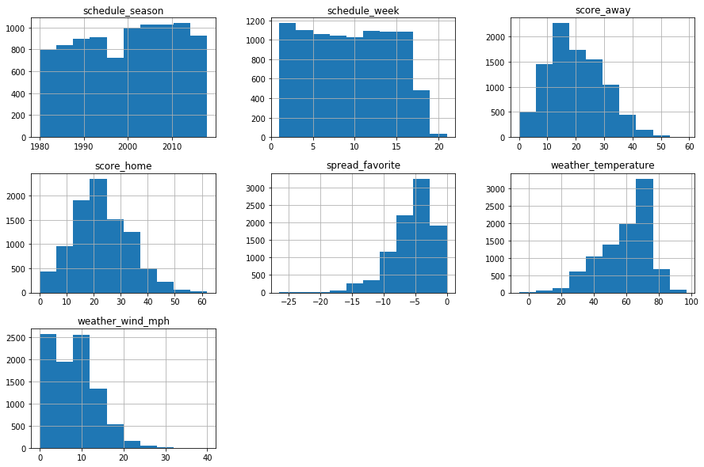

```python
num_nfl_scores = nfl_scores[["schedule_season","schedule_week","spread_favorite",
                            "weather_temperature","weather_wind_mph","score_home","score_away"]]
num_nfl_scores.hist(figsize=(15,10))
```

```python
correlations = nfl_scores.corr()
correlations['spread_favorite'].sort_values(ascending=False)
```

```
spread_favorite        1.000000
score_away             0.125770
weather_temperature    0.066207
stadium_neutral        0.010537
schedule_season       -0.015780
weather_wind_mph      -0.028922
schedule_week         -0.076689
score_home            -0.140107
Name: spread_favorite, dtype: float64
```

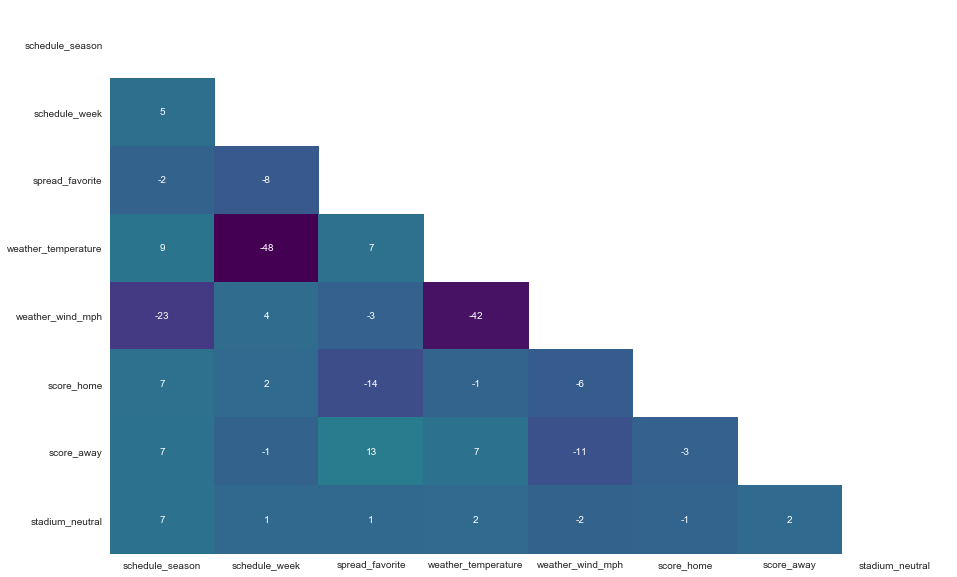

```python
sns.set_style("white")
mask = np.zeros_like(correlations , dtype=np.bool)
mask[np.triu_indices_from(mask)] = True
plt.figure(figsize=(15,10))
sns.heatmap(correlations*100,
            annot=True,fmt='.0f',
            mask=mask, cbar=False,cmap='viridis')
```

### EDA for NFL Teams

#### Find the total number of teams

There are 33 unique teams.

```python
unique_teams = nfl_teams['team_name_short'].unique()
print('# of Unique Teams (all eras)',len(unique_teams))
unique_teams
```

```
# of Unique Teams (all eras) 33
```

```
array(['Cardinals', 'Falcons', 'Ravens', 'Bills', 'Panthers', 'Bears',
       'Bengals', 'Browns', 'Cowboys', 'Broncos', 'Lions', 'Packers',
       'Texans', 'Colts', 'Jaguars', 'Chiefs', 'Chargers', 'Rams',
       'Dolphins', 'Vikings', 'Patriots', 'Saints', 'Giants', 'Jets',
       'Raiders', 'Eagles', 'Steelers', 'Seahawks', '49ers', 'Buccaneers',
       'Oilers', 'Titans', 'Redskins'], dtype=object)
```

#### Find the teams who have moved cities

Seven teams have moved (listed below) with the Cardinals moving the most (3 times)

```python
team_counts = nfl_teams['team_name_short'].value_counts()
moved_teams = team_counts[team_counts>1]

print('# of Moved Teams', len(moved_teams))
moved_teams
```

```
# of Moved Teams 7
```

```
Cardinals    3
Chargers     2
Oilers       2
Rams         2
Raiders      2
Patriots     2
Colts        2
Name: team_name_short, dtype: int64
```

#### For those teams that moved cities, find which cities they were associated with.

```python
all_cities = []

for i in moved_teams.index:
    full_names = nfl_teams[nfl_teams['team_name_short']==i]['team_name'].tolist()
    cities = [x.replace(i,'') for x in full_names]
    all_cities.append(cities)

pd.DataFrame({'Team':moved_teams.index,
              'Cities':all_cities})
```

|  | Team | Cities |
| --- | --- | --- |
| 0 | Cardinals | [Arizona , Phoenix , St. Louis ] |
| 1 | Chargers | [Los Angeles , San Diego ] |
| 2 | Oilers | [Houston , Tennessee ] |
| 3 | Rams | [Los Angeles , St. Louis ] |
| 4 | Raiders | [Los Angeles , Oakland ] |
| 5 | Patriots | [New England , Boston ] |
| 6 | Colts | [Baltimore , Indianapolis ] |

#### Which teams are no longer around?

```python
extinct_teams = nfl_teams.team_name[nfl_teams.team_division.isna()]
extinct_teams
```

```
1       Phoenix Cardinals
2     St. Louis Cardinals
15        Baltimore Colts
22         St. Louis Rams
26        Boston Patriots
30    Los Angeles Raiders
37         Houston Oilers
38       Tennessee Oilers
Name: team_name, dtype: object
```

#### For the teams that are no longer around, which franchises did they become?

```python
current_team_names = nfl_teams.team_name_short[nfl_teams.team_division.isna()].unique()

nfl_teams.team_name[(nfl_teams.team_name_short.isin(current_team_names)) & (nfl_teams.team_division.notna())]
```

```
0        Arizona Cardinals
16      Indianapolis Colts
21        Los Angeles Rams
25    New England Patriots
31         Oakland Raiders
Name: team_name, dtype: object
```

```python
new_teams = nfl_teams.team_name[nfl_teams.team_division_pre2002.isna()]

for team in new_teams:
    if team not in extinct_teams.tolist():
        print(team)
```

```
Houston Texans
```

#### How many teams are in each division

```python
curr_div = nfl_teams.team_division.value_counts()
curr_div
```

```
AFC West     5
AFC South    4
AFC North    4
NFC East     4
NFC South    4
AFC East     4
NFC North    4
NFC West     4
Name: team_division, dtype: int64
```

#### How many teams are in each division pre-2002

```python
pre_2002_div = nfl_teams.team_division_pre2002.value_counts()
pre_2002_div
```

```
AFC Central    8
AFC West       7
NFC West       7
AFC East       6
NFC East       6
NFC Central    5
Name: team_division_pre2002, dtype: int64
```

```python
nfl_teams[nfl_teams.team_division != nfl_teams.team_division_pre2002].dropna()
```

|  | team_name | team_name_short | team_id | team_id_pfr | team_conference | team_division | team_conference_pre2002 | team_division_pre2002 |
| --- | --- | --- | --- | --- | --- | --- | --- | --- |
| 3 | Atlanta Falcons | Falcons | ATL | ATL | NFC | NFC South | NFC | NFC West |
| 4 | Baltimore Ravens | Ravens | BAL | RAV | AFC | AFC North | AFC | AFC Central |
| 6 | Carolina Panthers | Panthers | CAR | CAR | NFC | NFC South | NFC | NFC West |
| 7 | Chicago Bears | Bears | CHI | CHI | NFC | NFC North | NFC | NFC Central |
| 8 | Cincinnati Bengals | Bengals | CIN | CIN | AFC | AFC North | AFC | AFC Central |
| 9 | Cleveland Browns | Browns | CLE | CLE | AFC | AFC North | AFC | AFC Central |
| 12 | Detroit Lions | Lions | DET | DET | NFC | NFC North | NFC | NFC Central |
| 13 | Green Bay Packers | Packers | GB | GNB | NFC | NFC North | NFC | NFC Central |
| 16 | Indianapolis Colts | Colts | IND | CLT | AFC | AFC South | AFC | AFC East |
| 17 | Jacksonville Jaguars | Jaguars | JAX | JAX | AFC | AFC South | AFC | AFC Central |
| 24 | Minnesota Vikings | Vikings | MIN | MIN | NFC | NFC North | NFC | NFC Central |
| 27 | New Orleans Saints | Saints | NO | NOR | NFC | NFC South | NFC | NFC West |
| 33 | Pittsburgh Steelers | Steelers | PIT | PIT | AFC | AFC North | AFC | AFC Central |
| 34 | Seattle Seahawks | Seahawks | SEA | SEA | NFC | NFC West | AFC | AFC West |
| 36 | Tampa Bay Buccaneers | Buccaneers | TB | TAM | NFC | NFC South | NFC | NFC Central |
| 39 | Tennessee Titans | Titans | TEN | OTI | AFC | AFC South | AFC | AFC Central |

```python
nfl_teams.team_conference.value_counts()
```

```
AFC    21
NFC    20
Name: team_conference, dtype: int64
```

```python
nfl_teams.team_conference_pre2002.value_counts()
```

```
AFC    22
NFC    19
Name: team_conference_pre2002, dtype: int64
```

```python
nfl_teams[nfl_teams.team_conference != nfl_teams.team_conference_pre2002].dropna()
```

|  | team_name | team_name_short | team_id | team_id_pfr | team_conference | team_division | team_conference_pre2002 | team_division_pre2002 |
| --- | --- | --- | --- | --- | --- | --- | --- | --- |
| 34 | Seattle Seahawks | Seahawks | SEA | SEA | NFC | NFC West | AFC | AFC West |

### EDA for NFL Stadiums

**Life of a Stadium**

- This shows the life of a stadium by how much is it active.
- The types of weather in these stadiums.
- This shows the map of the united states of where the stadiums are location.

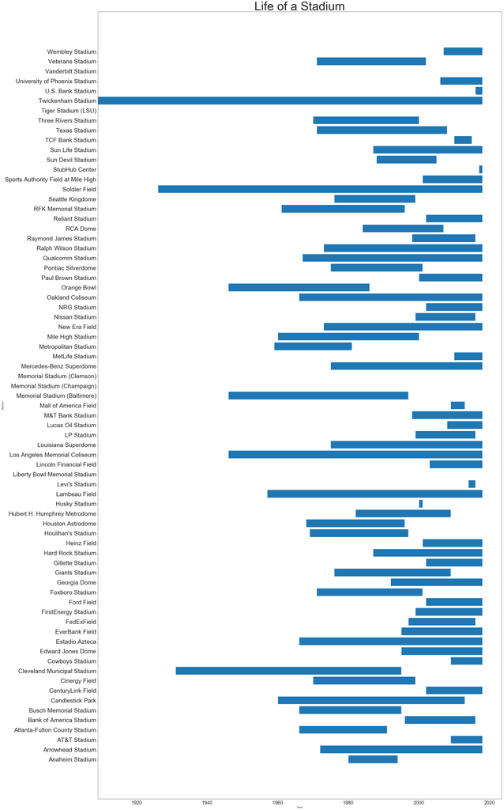

```python
fig_size = plt.rcParams["figure.figsize"]
fig_size[0] = 30
fig_size[1] = 60
plt.rcParams["figure.figsize"] = fig_size
begin = nfl_stadiums.stadium_open.values
end =   nfl_stadiums.stadium_close.values
event = nfl_stadiums.stadium_name.values

plt.barh(range(len(begin)),  end-begin, left=begin)
plt.xticks(fontsize=20)
plt.yticks(range(73), event, fontsize=25)
plt.title("Life of a Stadium", fontsize=50)
plt.xlabel("Years")
plt.ylabel("Stadium")
plt.show()
plt.savefig('LifeofaStadium.png')
```

```python
print ('Stadium Type -', "Counts")
nfl_stadiums.stadium_weather_type.value_counts()
```

```
Stadium Type - Counts
```

```
cold        23
dome        18
moderate    18
warm        14
Name: stadium_weather_type, dtype: int64
```

```python
cl = [ [0,"rgb(5, 10, 172)"],[0.35,"rgb(40, 60, 190)"],[0.5,"rgb(70, 100, 245)"],\
    [0.6,"rgb(90, 120, 245)"],[0.7,"rgb(106, 137, 247)"],[1,"rgb(220, 220, 220)"] ]

data = [ dict(
        type = 'scattergeo',
        locationmode = 'USA-states',
        lon = nfl_stadiums['LONGITUDE'],
        lat = nfl_stadiums['LATITUDE'],
        text = nfl_stadiums['stadium_name'],
        mode = 'markers',
        marker = dict(
            size = 8,
            opacity = 0.8,
            reversescale = True,
            autocolorscale = False,
            symbol = 'square',
            line = dict(
                width=1,
                color='rgba(102, 102, 102)'
            ),
            #colorscale = scl,
            cmin = 0,
            #color = 'blue',
            #cmax = df['cnt'].max(),
            #colorbar=dict(
                title="Incoming flightsFebruary 2011"
            )
        )]

layout = dict(
        title = 'Map of all Stadiums in the United States)',
        colorbar = True,
        geo = dict(
            scope='usa',
            projection=dict( type='albers usa' ),
            showland = True,
            landcolor = "rgb(250, 250, 250)",
            subunitcolor = "rgb(217, 217, 217)",
            countrycolor = "rgb(217, 217, 217)",
            countrywidth = 0.5,
            subunitwidth = 0.5
        ),
    )

fig = dict( data=data, layout=layout )
py.iplot( fig, validate=False, filename='NFL Stadium' )
```

[interactive chart not shown]

## Change Name mappings

There were some inconsistancies in the data set. For example, the Chicago Bears were referenced by CHI and Chicago Bears. So made all the name callings but the short two or three letter code.

```python
name_mappings = [('ATL','Atlanta Falcons'),
                 ('BUF', 'Buffalo Bills'),
                 ('JAX','Jacksonville Jaguars'),
                 ('DAL', 'Dallas Cowboys'),
                 ('GB', 'Green Bay Packers'),
                 ('IND','Indianapolis Colts'),
                 ('MIA', 'Miami Dolphins'),
                 ('MIN','Minnesota Vikings'),
                 ('TB', 'Tampa Bay Buccaneers'),
                 ('NYG','New York Giants'),
                 ('OAK', 'Oakland Raiders'),
                 ('BAL','Baltimore Ravens'),
                 ('WAS', 'Washington Redskins'),
                 ('LAR', 'Los Angeles Rams'),
                 ('ARI', 'Arizona Cardinals'),
                 ('CIN', 'Cincinnati Bengals'),
                 ('DEN', 'Denver Broncos'),
                 ('PHI', 'Philadelphia Eagles'),
                 ('LAC','Los Angeles Chargers'),
                 ('CAR','Carolina Panthers'),
                 ('TEN','Tennessee Titans'),
                 ('NYJ', 'New York Jets'),
                 ('CHI', 'Chicago Bears'),
                 ('STL', 'St. Louis Rams'),
                 ('PIT', 'Pittsburgh Steelers'),
                 ('KC', 'Kansas City Chiefs'),
                 ('SD', 'San Diego Chargers'),
                 ('NE','New England Patriots'),
                 ('SEA','Seattle Seahawks'),
                 ('NO', 'New Orleans Saints'),
                 ('DET', 'Detroit Lions'),
                 ('SF', 'San Francisco 49ers'),
                 ('CLE', 'Cleveland Browns'),
                 ('HOU', 'Houston Texans'),
                 ('TEN','Houston Oilers'),
                 ('OAK','Los Angeles Raiders'),
                 ('ARI','St. Louis Cardinals'),
                 ('ARI','Phoenix Cardinals'),
                 ('IND','Baltimore Colts'),
                 ('TEN','Tennessee Oilers')]

for mapping in name_mappings:
    nfl_scores.team_away.replace(mapping[1], mapping[0],inplace=True)
    nfl_scores.team_home.replace(mapping[1], mapping[0],inplace=True)
```

## Create Target Variable

**This creates the target variable of what we will be calculating. We are baseing this on the home team and how the differential between the scores is.**

```python
y=nfl_scores["score_home"]-nfl_scores["score_away"]
```

## Numerical and Catergorical Pipelines

```python
X_train, X_other, y_train, y_other=train_test_split(nfl_scores,y, test_size=0.2, random_state=42)
X_test, X_val, y_test, y_val=train_test_split(X_other,y_other, test_size=0.5, random_state=42)
```

```python
num_attribs=['schedule_season',
        'spread_favorite', 'over_under_line',
       'weather_temperature', 'weather_wind_mph', 'score_home', 'score_away']
cat_attribs=['schedule_week','team_home', 'team_away','stadium','team_favorite_id','stadium_neutral']
```

```python
num_pipeline = Pipeline([
        ('selector', DataFrameSelector(num_attribs)),
        ('imputer', Imputer(strategy="median")),
        ('std_scaler', StandardScaler()),
    ])
cat_pipeline = Pipeline([
        ('selector', DataFrameSelector(cat_attribs)),
        ('cat_encoder', CategoricalEncoder(encoding="onehot-dense"))
    ])
full_pipeline = FeatureUnion(transformer_list=[
        ("num_pipeline", num_pipeline),
        ("cat_pipeline", cat_pipeline),
    ])
```

```python
model = DummyRegressor(strategy='mean')
cv = ShuffleSplit(n_splits=30, test_size=0.3, random_state=42)
baseline_scores = cross_val_score(model, X_train, y_train, cv=cv, scoring='neg_mean_squared_error')
baseline_train_score = np.sqrt(-baseline_scores.mean())

start = time()
model.fit(X_train, y_train)
baseline_train_predict = model.fit(X_train, y_train)
train_time_bs = np.round(time()-start,3)

start = time()
baseline_test_predict = model.predict(X_val)
baseline_test_score = np.sqrt(mean_squared_error(y_val, baseline_test_predict))
test_time = np.round(time()-start,3)
```

```python
pipe=Pipeline([
    ('prestuff', full_pipeline),
    ('model', RandomForestClassifier())
])
```

```python
start = time()
rf_pipe=pipe.fit(X_train,y_train)
train_time_rf = np.round(time()-start,3)
```

```python
start = time()
y_pred=rf_pipe.predict(X_test)
test_time_rf = np.round(time()-start,3)
```

```python
rf_mse = mean_squared_error(y_pred, y_test)
rf_rmse = np.sqrt(rf_mse)
rf_rmse
```

```
9.31265215693566
```

```python
results = pd.DataFrame(columns=["ExpID", "Test RMSE", "p-value", "Train Time(s)", "Test Time(s)", "Experiment description"])
```

```python
results.loc[0] = ["Baseline", round(baseline_test_score, 4), "---", train_time_bs, test_time, "Baseline"]
results.loc[1] = ["RandomForest", round(rf_rmse, 4), "---", train_time_rf, test_time_rf, "Baseline RandomForest without hyperparameter tuning"]
```

### Results

```python
results
```

|  | ExpID | Test RMSE | p-value | Train Time(s) | Test Time(s) | Experiment description |
| --- | --- | --- | --- | --- | --- | --- |
| 0 | Baseline | 14.3205 | --- | 0.001 | 0.029 | Baseline |
| 1 | RandomForest | 9.3127 | --- | 0.574 | 0.029 | Baseline RandomForest without hyperparameter t... |